# latinR tweets

TuQmano

2019-09-30

Terminó nomás la segunda edición de [#LatinR](https://latin-r.com/). Tres días a pleno con *workshops*, exposiciones plenarias, presentaciones y posters. Diversidad de disciplinas, participantes de casi toda nuestramerica e invitados super grosos. Donde no solo aprendí cuestiones técnicas y nuevas herramientas, sino también el ejericio constante de reforzar el trabajo colaborativo dentro de una comunidad diversa y plural.

[figure not shown]

Yo en particular tuve la gran oportunidad además de (a) participar de un genial taller sobre el desarrollo de paquetes, con el messi de este lío (H.Wickham - arriba); y (b) mostrar parte del trabajo y aprendizaje desde aquel ya lejano `#LatinR2018`.

Acá se puede acceder al `shiny` app de [Inteligencia Electoral](http://inteligenciaelectoral.mentacomunicacion.com.ar/). Acá las [slides](https://www.researchgate.net/publication/336145088_Inteligencia_Electoral) de la presentación y acá el [abstract](https://www.researchgate.net/publication/336145098_Inteligencia_Electoral_comportamiento_y_campanas).

## `LatinR` en la red del pajarito

Twitter es un gran lugar para estar conectado con las novedades de [#rstats](https://twitter.com/search?q=rstatsES). Y `LatinR` nos dió la posibilidad de poder ponerle cara a un montón de `@rrobas` con los que uno interactúa cotidianamente en esa conexión. Algo de todo esto se pudo vivir a través de twitter detrás del *hashtag* `#LatinR2019`. Los gráficos de abajo son una muestra de eso.

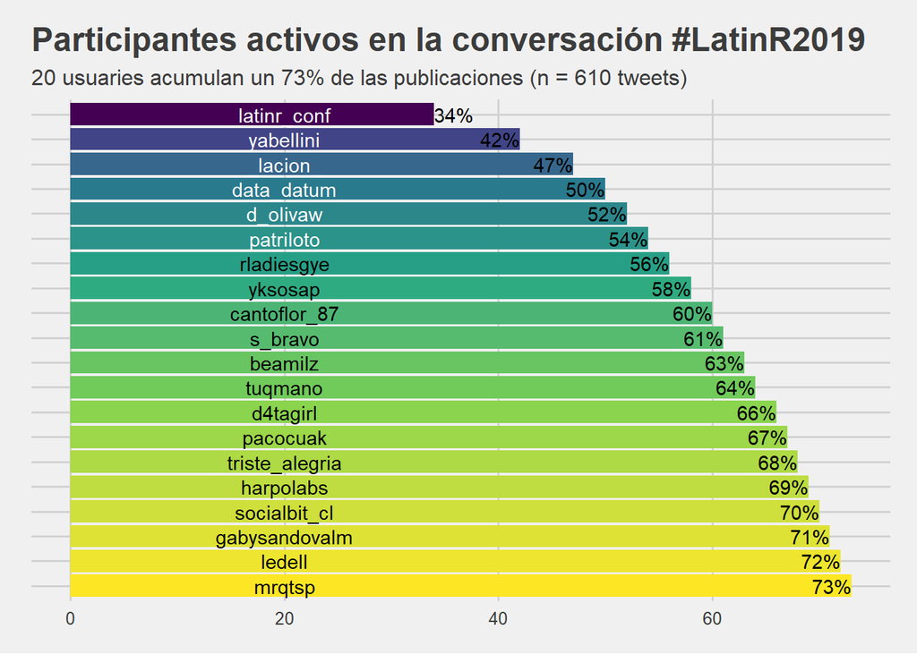

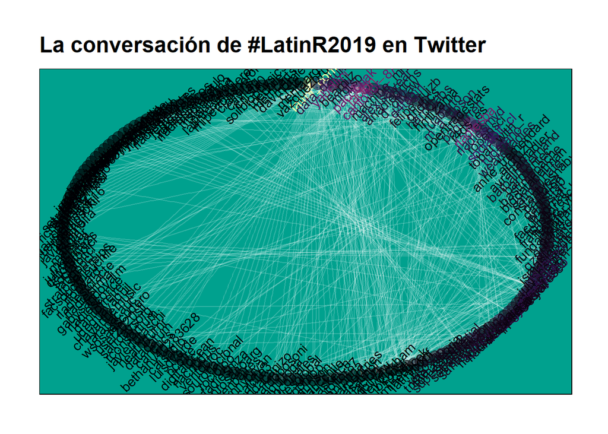

[Zoom](https://github.com/TuQmano/data_TuQmanoR/blob/master/latinr_network.png) al grafo.

Ya pasaron Buenos Aires (2018) y Santiago (2019). Llega el turno de `LatinR2020` en Montevideo.